# Project Report

2024-12-15

**Introduction:**

For our project we have chosen data set of Adidas from North America. We want to analyze it and predict which factors are the strongest predictors of profitability for Adidas products, which sales channel is the most effective for each product type in terms of sales and profitability and how do different factors influence the number of units sold. The insights will help Adidas to make better decisions about pricing, marketing, and distribution to improve business performance.

**Stakeholders’ implications:**

Adidas Management - Insights from the project can help with effective allocation of resources, with the purpose of maximization of profitability and sales.

Retail Partners – Improvement of forecasting the sales and profitability might be of assistance to better plan the inventory and foster collaborations with Adidas.

Customers - Indirectly benefit from optimized product availability and potentially better pricing.

**Based on statistic analysis Adidas can:**

-improve sales techniques (location, product specific discounting, better pricing strategy based on sales)

- optimize marketing (find marketing targets better, find products that fit the customers expectations better)

- implement IoT technologies (for dynamic pricing strategy, for better store experience - MobileApp)

Load important libraries:

```r
library(readxl)
library(rpart)
library(rpart.plot)
library(partykit)
library(ranger)
library(dplyr)
library(ggplot2)
```

Load in the data and take a first look: (https://www.kaggle.com/datasets/heemalichaudhari/adidas-sales-dataset)

```r
df <- read_excel("Adidas US Sales Datasets.xlsx")
```

```r
head(df)
```

```
## # A tibble: 6 × 13
##   ...1    Adidas Sales Databas…¹ ...3  ...4  ...5  ...6  ...7  ...8  ...9  ...10
##   <chr>   <chr>                  <chr> <chr> <chr> <chr> <chr> <chr> <chr> <chr>
## 1 <NA>    <NA>                   <NA>  <NA>  <NA>  <NA>  <NA>  <NA>  <NA>  <NA>
## 2 <NA>    <NA>                   <NA>  <NA>  <NA>  <NA>  <NA>  <NA>  <NA>  <NA>
## 3 Retail… Retailer ID            Invo… Regi… State City  Prod… Pric… Unit… Tota…
## 4 Foot L… 1185732                43831 Nort… New … New … Men'… 50    1200  6000…
## 5 Foot L… 1185732                43832 Nort… New … New … Men'… 50    1000  5000…
## 6 Foot L… 1185732                43833 Nort… New … New … Wome… 40    1000  4000…
## # ℹ abbreviated name: ¹`Adidas Sales Database`
## # ℹ 3 more variables: ...11 <chr>, ...12 <chr>, ...13 <chr>
```

This output shows us that we have to do some data cleaning before proceeding. We start by removing the first two rows, which only contain NA values and continue by setting the new first row as the header and removing it afterwards.

```r
df <- df[-c(1:2),] # remove first two rows
colnames(df) <- df[1,] # set first row as header
df <- df[-1,] # remove redundant first row

head(df)
```

```
## # A tibble: 6 × 13
##   Retailer    `Retailer ID` `Invoice Date` Region    State    City     Product
##   <chr>       <chr>         <chr>          <chr>     <chr>    <chr>    <chr>
## 1 Foot Locker 1185732       43831          Northeast New York New York Men's St…
## 2 Foot Locker 1185732       43832          Northeast New York New York Men's At…
## 3 Foot Locker 1185732       43833          Northeast New York New York Women's …
## 4 Foot Locker 1185732       43834          Northeast New York New York Women's …
## 5 Foot Locker 1185732       43835          Northeast New York New York Men's Ap…
## 6 Foot Locker 1185732       43836          Northeast New York New York Women's …
## # ℹ 6 more variables: `Price per Unit` <chr>, `Units Sold` <chr>,
## #   `Total Sales` <chr>, `Operating Profit` <chr>, `Operating Margin` <chr>,
## #   `Sales Method` <chr>
```

This looks already much better! The following code shows that there are no more missing values!

```r
sum(is.na(df))
```

```
## [1] 0
```

Now let us take a closer look at the structure of the data set.

```r
str(df)
```

```
## tibble [9,648 × 13] (S3: tbl_df/tbl/data.frame)
##  $ Retailer        : chr [1:9648] "Foot Locker" "Foot Locker" "Foot Locker" "Foot Locker" ...
##  $ Retailer ID     : chr [1:9648] "1185732" "1185732" "1185732" "1185732" ...
##  $ Invoice Date    : chr [1:9648] "43831" "43832" "43833" "43834" ...
##  $ Region          : chr [1:9648] "Northeast" "Northeast" "Northeast" "Northeast" ...
##  $ State           : chr [1:9648] "New York" "New York" "New York" "New York" ...
##  $ City            : chr [1:9648] "New York" "New York" "New York" "New York" ...
##  $ Product         : chr [1:9648] "Men's Street Footwear" "Men's Athletic Footwear" "Women's Street Footwear" "Women's Athletic Footwear" ...
##  $ Price per Unit  : chr [1:9648] "50" "50" "40" "45" ...
##  $ Units Sold      : chr [1:9648] "1200" "1000" "1000" "850" ...
##  $ Total Sales     : chr [1:9648] "600000" "500000" "400000" "382500" ...
##  $ Operating Profit: chr [1:9648] "300000" "150000" "140000" "133875" ...
##  $ Operating Margin: chr [1:9648] "0.5" "0.3" "0.35" "0.35" ...
##  $ Sales Method    : chr [1:9648] "In-store" "In-store" "In-store" "In-store" ...
```

We remove columns which are not useful for further analysis, such as “Retailer ID”, “Invoice Date” and “Operating Margin”.

```r
df <- df[,-c(2,3,12)]
```

Now we just change the column names to make them easier to work with:

```r
colnames(df) <- c("Retailer", "Region", "State", "City", "Product",
                  "Price_per_Unit", "Units_Sold", "Total_Sales",
                  "Profit", "Sales_Method")
```

We continue by assigning the correct data type to each column:

```r
numcol <- c("Price_per_Unit", "Units_Sold", "Total_Sales", "Profit")

for (col in colnames(df)) {
  if (!col %in% numcol) {
    df[[col]] <- as.factor(df[[col]])
  } else {
    df[[col]] <- as.numeric(df[[col]])
  }
}

str(df)
```

```
## tibble [9,648 × 10] (S3: tbl_df/tbl/data.frame)
##  $ Retailer      : Factor w/ 6 levels "Amazon","Foot Locker",..: 2 2 2 2 2 2 2 2 2 2 ...
##  $ Region        : Factor w/ 5 levels "Midwest","Northeast",..: 2 2 2 2 2 2 2 2 2 2 ...
##  $ State         : Factor w/ 50 levels "Alabama","Alaska",..: 32 32 32 32 32 32 32 32 32 32 ...
##  $ City          : Factor w/ 52 levels "Albany","Albuquerque",..: 36 36 36 36 36 36 36 36 36 36 ...
##  $ Product       : Factor w/ 6 levels "Men's Apparel",..: 3 2 6 5 1 4 3 2 6 5 ...
##  $ Price_per_Unit: num [1:9648] 50 50 40 45 60 50 50 50 40 45 ...
##  $ Units_Sold    : num [1:9648] 1200 1000 1000 850 900 1000 1250 900 950 825 ...
##  $ Total_Sales   : num [1:9648] 600000 500000 400000 382500 540000 ...
##  $ Profit        : num [1:9648] 300000 150000 140000 133875 162000 ...
##  $ Sales_Method  : Factor w/ 3 levels "In-store","Online",..: 1 1 1 1 1 1 1 3 3 3 ...
```

Now let us examine a summary about the data:

```r
summary(df)
```

```
##           Retailer          Region            State               City
##  Amazon       : 949   Midwest  :1872   California: 432   Portland   : 360
##  Foot Locker  :2637   Northeast:2376   Texas     : 432   Charleston : 288
##  Kohl's       :1030   South    :1728   Florida   : 360   Albuquerque: 216
##  Sports Direct:2032   Southeast:1224   New York  : 360   Atlanta    : 216
##  Walmart      : 626   West     :2448   Alabama   : 216   Birmingham : 216
##  West Gear    :2374                    Arizona   : 216   Boise      : 216
##                                        (Other)   :7632   (Other)    :8136
##                       Product     Price_per_Unit     Units_Sold
##  Men's Apparel            :1606   Min.   :  7.00   Min.   :   0.0
##  Men's Athletic Footwear  :1610   1st Qu.: 35.00   1st Qu.: 106.0
##  Men's Street Footwear    :1610   Median : 45.00   Median : 176.0
##  Women's Apparel          :1608   Mean   : 45.22   Mean   : 256.9
##  Women's Athletic Footwear:1606   3rd Qu.: 55.00   3rd Qu.: 350.0
##  Women's Street Footwear  :1608   Max.   :110.00   Max.   :1275.0
##
##   Total_Sales         Profit         Sales_Method
##  Min.   :     0   Min.   :     0   In-store:1740
##  1st Qu.:  4254   1st Qu.:  1922   Online  :4889
##  Median :  9576   Median :  4371   Outlet  :3019
##  Mean   : 93273   Mean   : 34425
##  3rd Qu.:150000   3rd Qu.: 52062
##  Max.   :825000   Max.   :390000
##
```

The high numbers in “Price_per_Unit”, “Units_Sold”, “Total_Sales” and “Profit” might indicate outliers, so we use the IQR to find out how many there might be. We are only dealing with financial columns when it comes to outliers, so we decided to use a high boundary for determining the thresholds (hence k = 2) because it is very likely that there are some products which produced a very high profit or was sold a lot of times.

```r
find_outlier_count <- function(column) {
  Q1 <- quantile(column, 0.25)
  Q3 <- quantile(column, 0.75)
  IQR <- Q3 - Q1

  lower_bound <- Q1 - 2 * IQR
  upper_bound <- Q3 + 2 * IQR

  outliers <- column[column < lower_bound | column > upper_bound]

  num_outliers <- length(outliers)

  return(list(
    Lower_Bound = lower_bound,
    Upper_Bound = upper_bound,
    Num_of_Outliers = num_outliers
  ))
}

# columns to analyze for outliers
columns_to_check <- c("Price_per_Unit", "Units_Sold", "Total_Sales", "Profit")

# apply the function and display results
outlier_results <- lapply(df[columns_to_check], find_outlier_count)

# Print the results for each column
for (column_name in columns_to_check) {
  cat("Results for", column_name, "\n")
  print(outlier_results[[column_name]][c("Lower_Bound", "Upper_Bound", "Num_of_Outliers")])
}
```

```
## Results for Price_per_Unit
## $Lower_Bound
## 25%
##  -5
##
## $Upper_Bound
## 75%
##  95
##
## $Num_of_Outliers
## [1] 22
##
## Results for Units_Sold
## $Lower_Bound
##  25%
## -382
##
## $Upper_Bound
## 75%
## 838
##
## $Num_of_Outliers
## [1] 215
##
## Results for Total_Sales
## $Lower_Bound
##       25%
## -287236.5
##
## $Upper_Bound
##    75%
## 441491
##
## $Num_of_Outliers
## [1] 357
##
## Results for Profit
## $Lower_Bound
##       25%
## -98359.74
##
## $Upper_Bound
##    75%
## 152344
##
## $Num_of_Outliers
## [1] 453
```

We now just remove those rows which exceed the upper thresholds, removing 580 rows or 6% of the data set.

```r
# Extract the upper thresholds from the results
upper_thresholds <- sapply(outlier_results, function(result) result$Upper_Bound)

# Keep only rows that do not exceed the upper thresholds
dfx <- df[!apply(df[columns_to_check], 1, function(row) {
  any(row > upper_thresholds)
}), ]
```

Now then we have cleaned the data, we can focus on our first research question:

1. **What factors are the strongest predictors for profitability?**

We are interested in factors only and since it is obvious that the profit is going to have a positive relationship with Units_Sold and Total_Sales, we decided to exclude them as well as Price_per_Unit, since it is also not a factor. However, we have to keep in mind that the R2 will therefore be much lower and that all the numeric variables are always dominating trees and random forests in this particular data set!

```r
df1 <- dfx[,-c(6,7,8)]

str(df1)
```

```
## tibble [9,068 × 7] (S3: tbl_df/tbl/data.frame)
##  $ Retailer    : Factor w/ 6 levels "Amazon","Foot Locker",..: 2 2 2 4 4 4 4 4 4 4 ...
##  $ Region      : Factor w/ 5 levels "Midwest","Northeast",..: 2 2 2 2 2 3 3 3 3 3 ...
##  $ State       : Factor w/ 50 levels "Alabama","Alaska",..: 32 32 32 32 32 43 43 43 43 43 ...
##  $ City        : Factor w/ 52 levels "Albany","Albuquerque",..: 36 36 36 36 36 23 23 23 23 23 ...
##  $ Product     : Factor w/ 6 levels "Men's Apparel",..: 5 5 5 6 5 1 4 6 5 1 ...
##  $ Profit      : num [1:9068] 129938 126000 129938 85750 110250 ...
##  $ Sales_Method: Factor w/ 3 levels "In-store","Online",..: 3 3 3 3 3 3 3 3 3 3 ...
```

Let us take a closer look at some visualizations:

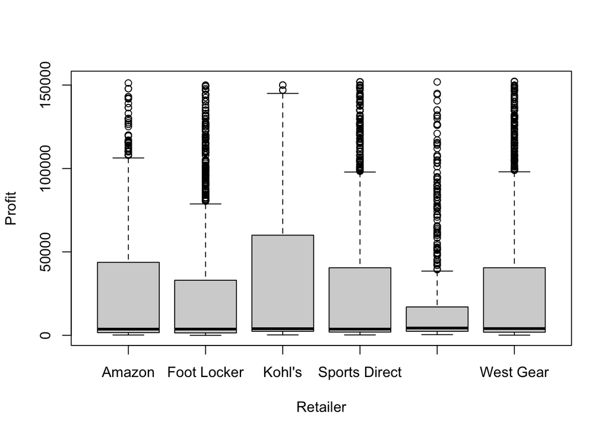

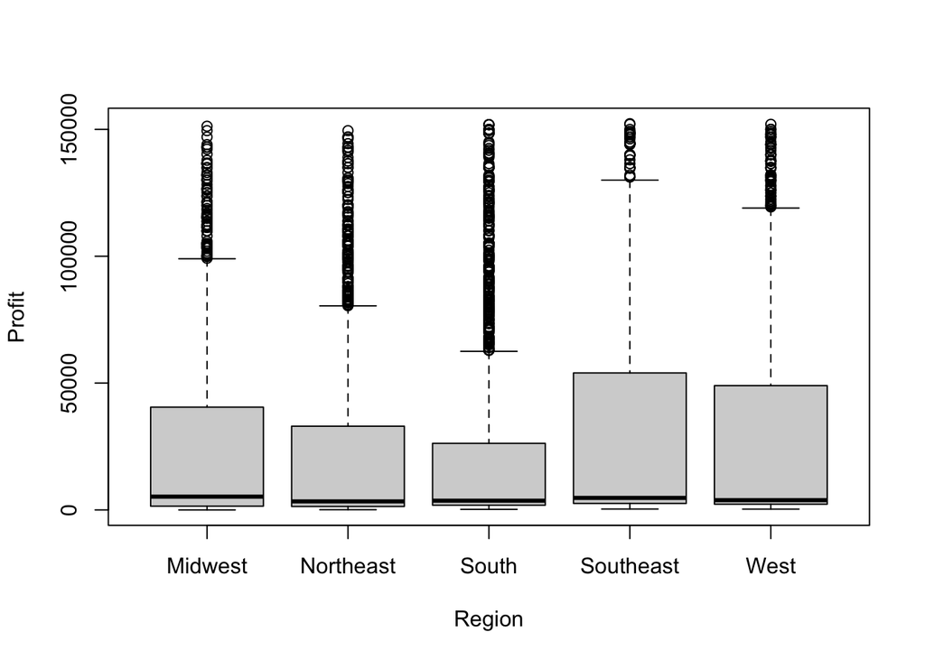

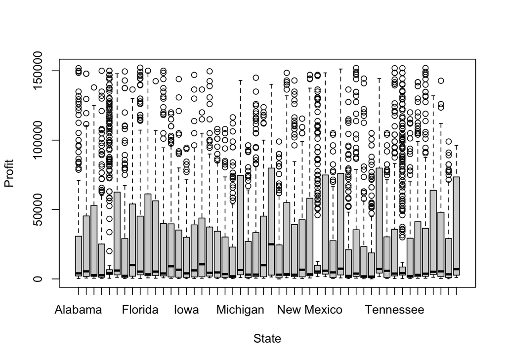

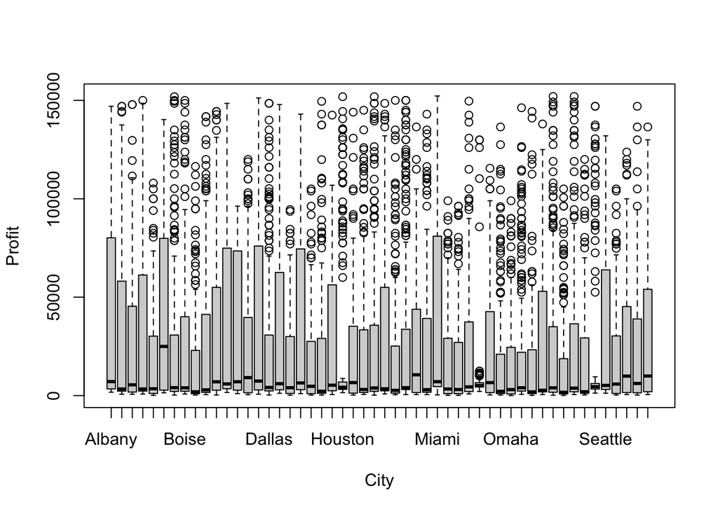

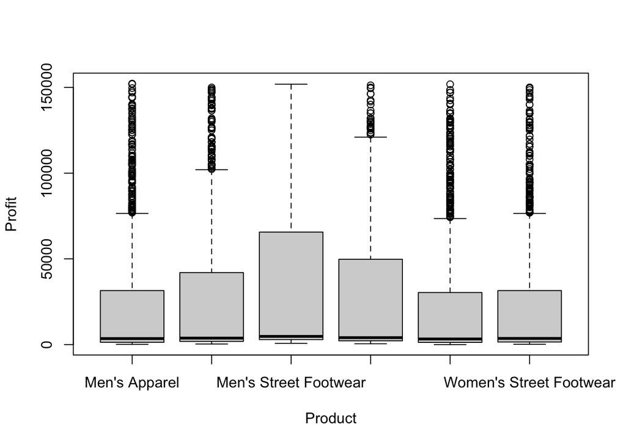

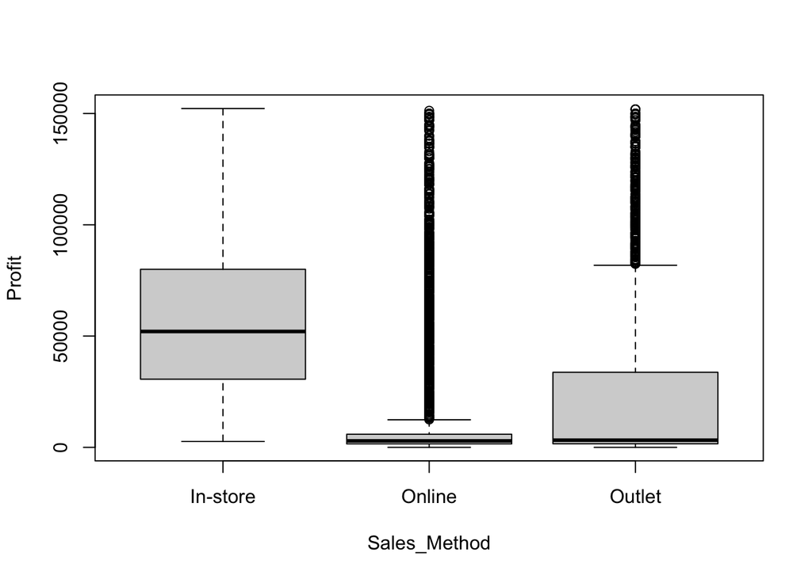

```r
plot(Profit ~ ., data = df1)
```

Solely by looking at these visualizations, Sales_Method seems to have very different effects on profit, with In-store being the most important level. We now split the data into a training set and test set.

```r
set.seed(159)
idx <- sample(1:nrow(df1), size = 0.8 * nrow(df1), replace = FALSE)

trainData <- df1[idx, ]
testData <- df1[-idx, ]
```

```r
train1 <- lm(Profit ~ ., data = df1)

summary(train1)
```

```
##
## Call:
## lm(formula = Profit ~ ., data = df1)
##
## Residuals:
##    Min     1Q Median     3Q    Max
## -62098 -19916  -7534   8941 139742
##
## Coefficients: (51 not defined because of singularities)
##                                   Estimate Std. Error t value Pr(>|t|)
## (Intercept)                       41638.47    3717.43  11.201  < 2e-16 ***
## RetailerFoot Locker                2187.52    2262.60   0.967 0.333661
## RetailerKohl's                     5483.49    2852.96   1.922 0.054632 .
## RetailerSports Direct              5652.20    2315.40   2.441 0.014660 *
## RetailerWalmart                    2810.71    2979.97   0.943 0.345604
## RetailerWest Gear                  3760.21    2593.11   1.450 0.147072
## RegionNortheast                    9363.38    3610.22   2.594 0.009514 **
## RegionSouth                       26027.14    3840.90   6.776 1.31e-11 ***
## RegionSoutheast                   14945.64    3694.57   4.045 5.27e-05 ***
## RegionWest                        16099.43    4117.88   3.910 9.31e-05 ***
## StateAlaska                       21718.88    4418.77   4.915 9.03e-07 ***
## StateArizona                      16042.85    3577.03   4.485 7.38e-06 ***
## StateArkansas                      1000.03    3501.72   0.286 0.775204
## StateCalifornia                    8869.89    3968.08   2.235 0.025421 *
## StateColorado                      4685.93    4227.17   1.109 0.267664
## StateConnecticut                  -3861.77    3546.43  -1.089 0.276219
## StateDelaware                      3171.11    3779.89   0.839 0.401525
## StateFlorida                       4010.55    3451.09   1.162 0.245222
## StateGeorgia                      19393.47    3114.34   6.227 4.96e-10 ***
## StateHawaii                       19022.09    4122.47   4.614 4.00e-06 ***
## StateIdaho                        14494.98    3735.58   3.880 0.000105 ***
## StateIllinois                     33479.17    3967.19   8.439  < 2e-16 ***
## StateIndiana                       4016.85    3572.07   1.125 0.260824
## StateIowa                            80.95    3750.53   0.022 0.982780
## StateKansas                       33174.09    4036.20   8.219 2.33e-16 ***
## StateKentucky                     25114.09    3730.49   6.732 1.77e-11 ***
## StateLouisiana                    -3613.54    3484.17  -1.037 0.299703
## StateMaine                        21198.60    4284.13   4.948 7.63e-07 ***
## StateMaryland                     -9555.40    3652.55  -2.616 0.008909 **
## StateMassachusetts                -6889.87    3622.00  -1.902 0.057173 .
```

[output cut: 78 more lines]

```
## CityWichita                             NA         NA      NA       NA
## CityWilmington                          NA         NA      NA       NA
## ProductMen's Athletic Footwear     2733.86    1094.45   2.498 0.012510 *
## ProductMen's Street Footwear      11744.36    1112.56  10.556  < 2e-16 ***
## ProductWomen's Apparel             4967.66    1107.99   4.483 7.43e-06 ***
## ProductWomen's Athletic Footwear   -786.34    1084.10  -0.725 0.468264
## ProductWomen's Street Footwear     -563.72    1091.24  -0.517 0.605460
## Sales_MethodOnline               -57928.90    1009.31 -57.394  < 2e-16 ***
## Sales_MethodOutlet               -48648.77    1168.84 -41.622  < 2e-16 ***
## ---
## Signif. codes:  0 '***' 0.001 '**' 0.01 '*' 0.05 '.' 0.1 ' ' 1
##
## Residual standard error: 30310 on 9002 degrees of freedom
## Multiple R-squared:  0.3032, Adjusted R-squared:  0.2981
## F-statistic: 60.25 on 65 and 9002 DF,  p-value: < 2.2e-16
```

We now conduct a stepwise regression analysis:

```r
train2 <- step(train1, direction = "backward")
```

```
## Start:  AIC=187215.4
## Profit ~ Retailer + Region + State + City + Product + Sales_Method
##
##
## Step:  AIC=187215.4
## Profit ~ Retailer + Region + City + Product + Sales_Method
##
##                Df  Sum of Sq        RSS    AIC
## <none>                       8.2701e+12 187215
## - Retailer      5 1.0789e+10 8.2809e+12 187217
## - Region        2 1.0180e+11 8.3719e+12 187322
## - Product       5 1.7045e+11 8.4406e+12 187390
## - City         49 7.4008e+11 9.0102e+12 187895
## - Sales_Method  2 3.0267e+12 1.1297e+13 190039
```

```r
summary(train2)
```

```
##
## Call:
## lm(formula = Profit ~ Retailer + Region + City + Product + Sales_Method,
##     data = df1)
##
## Residuals:
##    Min     1Q Median     3Q    Max
## -62098 -19916  -7534   8941 139742
##
## Coefficients: (2 not defined because of singularities)
##                                  Estimate Std. Error t value Pr(>|t|)
## (Intercept)                       74812.6     3772.1  19.833  < 2e-16 ***
## RetailerFoot Locker                2187.5     2262.6   0.967 0.333661
## RetailerKohl's                     5483.5     2853.0   1.922 0.054632 .
## RetailerSports Direct              5652.2     2315.4   2.441 0.014660 *
## RetailerWalmart                    2810.7     2980.0   0.943 0.345604
## RetailerWest Gear                  3760.2     2593.1   1.450 0.147072
## RegionNortheast                   -6454.6     4000.0  -1.614 0.106641
## RegionSouth                      -10225.4     3489.1  -2.931 0.003391 **
## RegionSoutheast                   34082.2     5417.9   6.291 3.31e-10 ***
## RegionWest                       -23706.5     6008.7  -3.945 8.03e-05 ***
## CityAlbuquerque                   24007.0     5870.3   4.090 4.36e-05 ***
## CityAnchorage                     28350.7     6914.8   4.100 4.17e-05 ***
## CityAtlanta                      -32917.2     5216.9  -6.310 2.93e-10 ***
## CityBaltimore                    -26911.5     3832.2  -7.022 2.34e-12 ***
## CityBillings                      13245.5     3629.6   3.649 0.000264 ***
## CityBirmingham                     3078.5     3409.2   0.903 0.366553
## CityBoise                         21126.8     5707.1   3.702 0.000215 ***
## CityBoston                       -24246.0     3807.4  -6.368 2.01e-10 ***
## CityBurlington                   -11744.0     4175.3  -2.813 0.004923 **
## CityCharleston                   -17356.1     3748.9  -4.630 3.71e-06 ***
## CityCharlotte                    -21052.1     5566.7  -3.782 0.000157 ***
## CityCheyenne                       6631.9     6027.9   1.100 0.271274
## CityChicago                         305.1     3828.9   0.080 0.936495
## CityColumbus                      19980.4     4379.1   4.563 5.12e-06 ***
## CityDallas                         3093.5     3406.2   0.908 0.363801
## CityDenver                        11317.8     5598.6   2.022 0.043252 *
## CityDes Moines                   -33093.1     3830.2  -8.640  < 2e-16 ***
## CityDetroit                      -12536.7     3998.9  -3.135 0.001724 **
## CityFargo                        -29557.7     3869.9  -7.638 2.44e-14 ***
```

[output cut: 30 more lines]

```
## CityWichita                            NA         NA      NA       NA
## CityWilmington                   -14185.0     3935.2  -3.605 0.000314 ***
## ProductMen's Athletic Footwear     2733.9     1094.5   2.498 0.012510 *
## ProductMen's Street Footwear      11744.4     1112.6  10.556  < 2e-16 ***
## ProductWomen's Apparel             4967.7     1108.0   4.483 7.43e-06 ***
## ProductWomen's Athletic Footwear   -786.3     1084.1  -0.725 0.468264
## ProductWomen's Street Footwear     -563.7     1091.2  -0.517 0.605460
## Sales_MethodOnline               -57928.9     1009.3 -57.394  < 2e-16 ***
## Sales_MethodOutlet               -48648.8     1168.8 -41.622  < 2e-16 ***
## ---
## Signif. codes:  0 '***' 0.001 '**' 0.01 '*' 0.05 '.' 0.1 ' ' 1
##
## Residual standard error: 30310 on 9002 degrees of freedom
## Multiple R-squared:  0.3032, Adjusted R-squared:  0.2981
## F-statistic: 60.25 on 65 and 9002 DF,  p-value: < 2.2e-16
```

```r
tree <- rpart(Profit ~ ., data = df1)

# plot(as.party(tree)) # the plotted tree is a mess, so we decided not to plot it by default

printcp(tree)
```

```
##
## Regression tree:
## rpart(formula = Profit ~ ., data = df1)
##
## Variables actually used in tree construction:
## [1] City         Product      Sales_Method State
##
## Root node error: 1.1868e+13/9068 = 1308796358
##
## n= 9068
##
##         CP nsplit rel error  xerror     xstd
## 1 0.177486      0   1.00000 1.00011 0.019764
## 2 0.061555      1   0.82251 0.82293 0.019532
## 3 0.032951      2   0.76096 0.76143 0.017366
## 4 0.030540      3   0.72801 0.73535 0.017171
## 5 0.018117      4   0.69747 0.68158 0.016461
## 6 0.017990      8   0.62500 0.62571 0.015050
## 7 0.010000     11   0.57103 0.60956 0.014695
```

The tree makes use of City, Product, Sales_Method and State, excluding Retailer and Region. Now it is time to prune the tree:

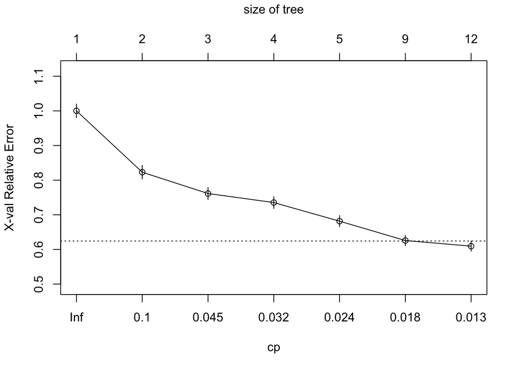

```r
plotcp(tree)
```

We use the 6th point from our diagram and use it to prune the tree:

[figure not shown]

```r
pruned_tree <- prune(tree, cp = tree$cptable[6, "CP"])
plot(as.party(pruned_tree))
```

```r
printcp(pruned_tree)
```

```
##
## Regression tree:
## rpart(formula = Profit ~ ., data = df1)
##
## Variables actually used in tree construction:
## [1] City         Product      Sales_Method State
##
## Root node error: 1.1868e+13/9068 = 1308796358
##
## n= 9068
##
##         CP nsplit rel error  xerror     xstd
## 1 0.177486      0   1.00000 1.00011 0.019764
## 2 0.061555      1   0.82251 0.82293 0.019532
## 3 0.032951      2   0.76096 0.76143 0.017366
## 4 0.030540      3   0.72801 0.73535 0.017171
## 5 0.018117      4   0.69747 0.68158 0.016461
## 6 0.017990      8   0.62500 0.62571 0.015050
```

Variables actually used in tree construction: City, Product, Sales_Method, State

The tree sees these variables as important factors, as it splits on them.

Let us now focus on the random forest, we are particularly interested in variable importance, since we want to find out, which factors have the highest effect on our response(Profit).

```r
rf <- ranger(Profit ~ ., data = df1,
             probability = FALSE,
             importance = "permutation")

print(rf)
```

```
## Ranger result
##
## Call:
##  ranger(Profit ~ ., data = df1, probability = FALSE, importance = "permutation")
##
## Type:                             Regression
## Number of trees:                  500
## Sample size:                      9068
## Number of independent variables:  6
## Mtry:                             2
## Target node size:                 5
## Variable importance mode:         permutation
## Splitrule:                        variance
## OOB prediction error (MSE):       707958494
## R squared (OOB):                  0.4591363
```

And plot the resulting permutation importance:

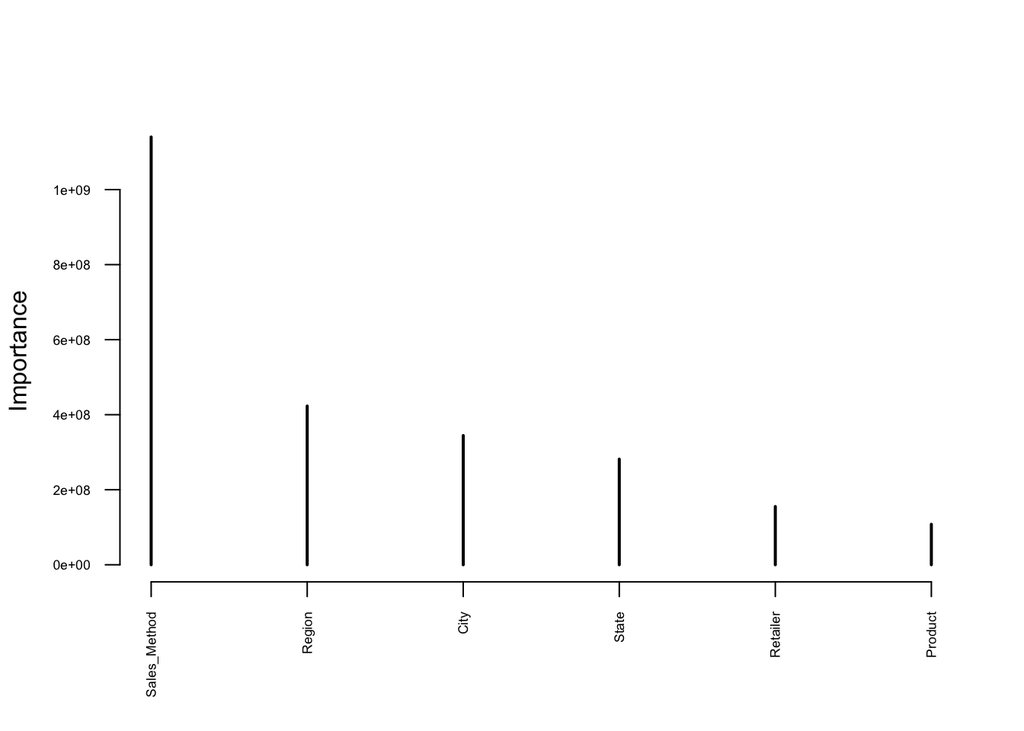

```r
importance_values <- importance(rf)
importance_sorted <- sort(importance_values, decreasing = TRUE)
plot(as.table(importance_sorted), ylab = "Importance", las = 2,  cex.axis = 0.55)
```

As we can observe, Sales Method seems to be the most important factor when it comes to predicting profit, this was backed by the pruned tree too. Since we have now seen all the different results which depend on the statistical method, we now want to perform a cross-validation and find the method, which produces the lowest MSE.

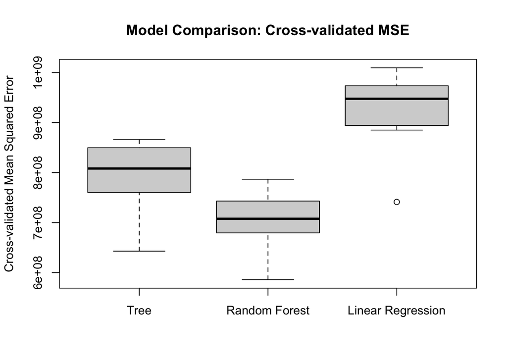

```r
n <- nrow(df1)
fold <- 10
folds <- sample(rep(1:fold, ceiling(n/fold)), n)
# head(folds, n = 10)

mse <- list(tree = numeric(fold), rf = numeric(fold), lm = numeric(fold))

for (tfold in seq_len(fold)) {
  # Split data into training and test sets
  train_idx <- which(folds != tfold)
  test_idx <- which(folds == tfold)

  # Fit models on the training set
  rf <- ranger(Profit ~ ., data = df1[train_idx, ], importance = "permutation")
  tree <- rpart(Profit ~ ., data = df1[train_idx, ], method = "anova")
  lm_model <- lm(Profit ~ ., data = df1[train_idx, ])

  # Make predictions on the test set
  p_rf <- predict(rf, data = df1[test_idx, ])$predictions
  p_tree <- predict(tree, newdata = df1[test_idx, ])
  p_lm <- predict(lm_model, newdata = df1[test_idx, ])

  # Calculate and store MSE
  actual <- df1$Profit[test_idx]
  mse$rf[tfold] <- mean((actual - p_rf)^2)
  mse$tree[tfold] <- mean((actual - p_tree)^2)
  mse$lm[tfold] <- mean((actual - p_lm)^2)
}

# Combine results into a data frame
mse_df <- data.frame(Tree = mse$tree, `Random Forest` = mse$rf, `Linear Regression` = mse$lm)

# Plot the cross-validated MSE
boxplot(mse_df, names = c("Tree", "Random Forest", "Linear Regression"),
        ylab = "Cross-validated Mean Squared Error",
        main = "Model Comparison: Cross-validated MSE")
```

As it is shown, the Random Forest outperforms the linear regression and the tree. So we come to conclusion that the Sales_Method is the most influential factor when it comes to the companies profit.

We now want to focus on our second research question:

2. **Which sales channel is most effective for each product type?**

In order to answer this question, we also start by visualizing it by first aggregating the data by Product and Sales_Method and using Units_Sold as the reference:

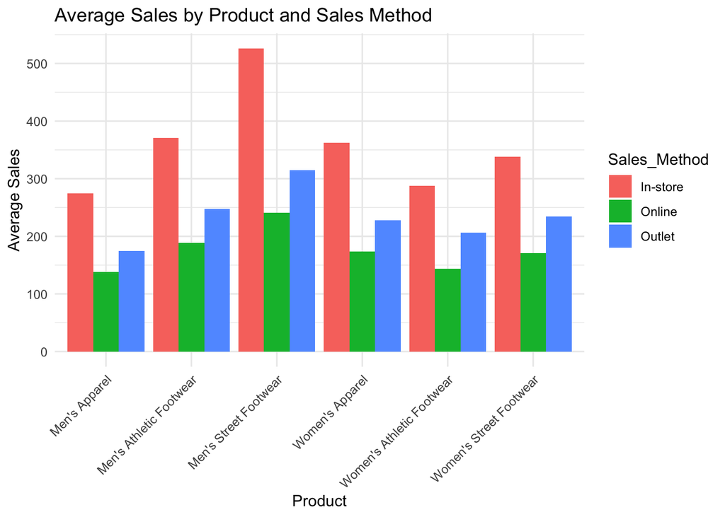

```r
agg_data <- dfx %>%
  group_by(Product, Sales_Method) %>%
  summarize(Average_Sales = mean(Units_Sold), .groups = 'drop')

ggplot(agg_data, aes(x = Product, y = Average_Sales, fill = Sales_Method)) +
  geom_bar(stat = "identity", position = "dodge") + # Adjust width of dodge
  labs(title = "Average Sales by Product and Sales Method",
       x = "Product",
       y = "Average Sales") +
  theme_minimal() +
  theme(axis.text.x = element_text(angle = 45, hjust = 1))
```

According to this simple bar chart, we observe that all products record the highest average sales when sold in-store. Furthermore, “Men’s Street Footwear” has the highest average sales in all methods of sales. The lowest average sales are recorded when sold online independent from the chosen product.

Let us use produce another plot:

```r
agg_summary <- dfx %>%
  group_by(Product, Sales_Method) %>%
  summarize(
    Mean_Sales = mean(Units_Sold, na.rm = TRUE),
    Median_Sales = median(Units_Sold, na.rm = TRUE),
    SD_Sales = sd(Units_Sold, na.rm = TRUE),
    .groups = 'drop'
  )
print(agg_summary)
```

```
## # A tibble: 18 × 5
##    Product                   Sales_Method Mean_Sales Median_Sales SD_Sales
##    <fct>                     <fct>             <dbl>        <dbl>    <dbl>
##  1 Men's Apparel             In-store           275.          225    152.
##  2 Men's Apparel             Online             138.           95    128.
##  3 Men's Apparel             Outlet             174.          136    132.
##  4 Men's Athletic Footwear   In-store           371.          325    156.
##  5 Men's Athletic Footwear   Online             189.          143    157.
##  6 Men's Athletic Footwear   Outlet             248.          203    171.
##  7 Men's Street Footwear     In-store           526.          525     92.3
##  8 Men's Street Footwear     Online             241.          176    164.
##  9 Men's Street Footwear     Outlet             315.          238    177.
## 10 Women's Apparel           In-store           363.          350    112.
## 11 Women's Apparel           Online             173.          126    126.
## 12 Women's Apparel           Outlet             228.          192    137.
## 13 Women's Athletic Footwear In-store           288.          250    166.
## 14 Women's Athletic Footwear Online             144.          101    135.
## 15 Women's Athletic Footwear Outlet             206.          145    175.
## 16 Women's Street Footwear   In-store           338.          300    147.
## 17 Women's Street Footwear   Online             171.          123    143.
## 18 Women's Street Footwear   Outlet             234.          175    172.
```

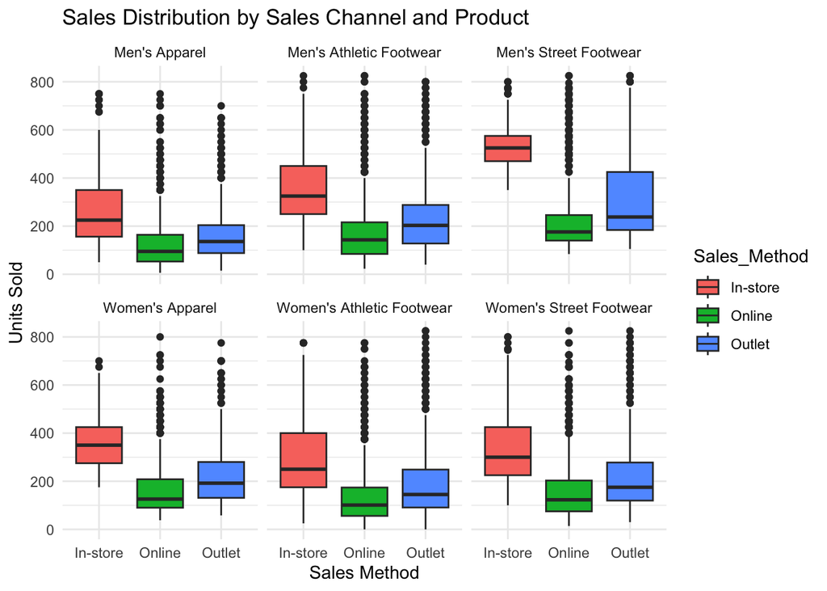

```r
# Boxplot for visualizing sales distributions
ggplot(dfx, aes(x = Sales_Method, y = Units_Sold, fill = Sales_Method)) +
  geom_boxplot() +
  facet_wrap(~ Product) +
  labs(
    title = "Sales Distribution by Sales Channel and Product",
    x = "Sales Method",
    y = "Units Sold"
  ) +
  theme_minimal()
```

According to these boxplots, the most effective sales channel for each product is In-Store.

Let us just fit a linear model on the data, using Units_Sold as the response and Product as well as Sales_Method as the independent variables.

```r
reg2 <- lm(Units_Sold ~ Product + Sales_Method, data = dfx)

summary(reg2)
```

```
##
## Call:
## lm(formula = Units_Sold ~ Product + Sales_Method, data = dfx)
##
## Residuals:
##     Min      1Q  Median      3Q     Max
## -294.17  -99.76  -45.62   46.63  654.63
##
## Coefficients:
##                                  Estimate Std. Error t value Pr(>|t|)
## (Intercept)                       304.215      5.128  59.320  < 2e-16 ***
## ProductMen's Athletic Footwear     65.601      5.405  12.136  < 2e-16 ***
## ProductMen's Street Footwear      137.820      5.492  25.095  < 2e-16 ***
## ProductWomen's Apparel             49.965      5.470   9.134  < 2e-16 ***
## ProductWomen's Athletic Footwear   14.955      5.354   2.793  0.00523 **
## ProductWomen's Street Footwear     46.566      5.389   8.640  < 2e-16 ***
## Sales_MethodOnline               -180.412      4.382 -41.169  < 2e-16 ***
## Sales_MethodOutlet               -122.418      4.751 -25.769  < 2e-16 ***
## ---
## Signif. codes:  0 '***' 0.001 '**' 0.01 '*' 0.05 '.' 0.1 ' ' 1
##
## Residual standard error: 149.7 on 9060 degrees of freedom
## Multiple R-squared:  0.211,  Adjusted R-squared:  0.2104
## F-statistic: 346.2 on 7 and 9060 DF,  p-value: < 2.2e-16
```

The multiple linear regression model suggests, that both variables are highly significant, and we also observe yet again that Online and Outlet as the methods of sales perform significantly worse when compared to their baseline, which is in-store. At this point we would like to find out whether or not the effect of one variable on Units_Sold depends on the level of the other variable. That is why we are fitting the data to an interaction model:

```r
reg_interaction <- lm(Units_Sold ~ Product * Sales_Method, data = dfx)

summary(reg_interaction)
```

```
##
## Call:
## lm(formula = Units_Sold ~ Product * Sales_Method, data = dfx)
##
## Residuals:
##     Min      1Q  Median      3Q     Max
## -271.21  -98.27  -46.19   38.83  653.83
##
## Coefficients:
##                                                     Estimate Std. Error t value
## (Intercept)                                          274.544      8.991  30.536
## ProductMen's Athletic Footwear                        96.668     12.835   7.532
## ProductMen's Street Footwear                         251.508     13.577  18.525
## ProductWomen's Apparel                                88.109     13.086   6.733
## ProductWomen's Athletic Footwear                      13.220     12.602   1.049
## ProductWomen's Street Footwear                        63.690     12.774   4.986
## Sales_MethodOnline                                  -136.199     10.412 -13.081
## Sales_MethodOutlet                                  -100.248     11.299  -8.873
## ProductMen's Athletic Footwear:Sales_MethodOnline    -46.271     14.833  -3.119
## ProductMen's Street Footwear:Sales_MethodOnline     -148.661     15.510  -9.585
## ProductWomen's Apparel:Sales_MethodOnline            -53.181     15.093  -3.523
## ProductWomen's Athletic Footwear:Sales_MethodOnline   -7.383     14.624  -0.505
## ProductWomen's Street Footwear:Sales_MethodOnline    -30.863     14.778  -2.088
## ProductMen's Athletic Footwear:Sales_MethodOutlet    -23.216     16.125  -1.440
## ProductMen's Street Footwear:Sales_MethodOutlet     -111.122     16.768  -6.627
## ProductWomen's Apparel:Sales_MethodOutlet            -34.487     16.376  -2.106
## ProductWomen's Athletic Footwear:Sales_MethodOutlet   18.541     15.844   1.170
## ProductWomen's Street Footwear:Sales_MethodOutlet     -3.788     16.041  -0.236
##                                                     Pr(>|t|)
## (Intercept)                                          < 2e-16 ***
## ProductMen's Athletic Footwear                      5.48e-14 ***
## ProductMen's Street Footwear                         < 2e-16 ***
## ProductWomen's Apparel                              1.76e-11 ***
## ProductWomen's Athletic Footwear                    0.294193
## ProductWomen's Street Footwear                      6.28e-07 ***
## Sales_MethodOnline                                   < 2e-16 ***
## Sales_MethodOutlet                                   < 2e-16 ***
## ProductMen's Athletic Footwear:Sales_MethodOnline   0.001818 **
## ProductMen's Street Footwear:Sales_MethodOnline      < 2e-16 ***
## ProductWomen's Apparel:Sales_MethodOnline           0.000428 ***
## ProductWomen's Athletic Footwear:Sales_MethodOnline 0.613658
## ProductWomen's Street Footwear:Sales_MethodOnline   0.036791 *
## ProductMen's Athletic Footwear:Sales_MethodOutlet   0.149976
## ProductMen's Street Footwear:Sales_MethodOutlet     3.62e-11 ***
## ProductWomen's Apparel:Sales_MethodOutlet           0.035237 *
## ProductWomen's Athletic Footwear:Sales_MethodOutlet 0.241940
## ProductWomen's Street Footwear:Sales_MethodOutlet   0.813344
## ---
## Signif. codes:  0 '***' 0.001 '**' 0.01 '*' 0.05 '.' 0.1 ' ' 1
##
## Residual standard error: 148.8 on 9050 degrees of freedom
## Multiple R-squared:  0.2216, Adjusted R-squared:  0.2201
## F-statistic: 151.5 on 17 and 9050 DF,  p-value: < 2.2e-16
```

The intercept represents in this case the baseline Units_Sold for the reference levels: When selling the baseline product (Men’s Apparel) using the baseline method (In-store), the expected Units_Sold is approximately 274.54. The interaction effects, e.g. ProductMen’s Athletic Footwear:Sales_MethodOnline, represent how the combined effect of Product and Sales_Method deviates from the additive effects of their stand alone effects. This means, that when selling Men’s Athletic Footwear online, Units_Sold are decreased significantly more than expected based on the individual effects of the product and sales method alone. Such a highly significant and negative effect can also be found by the following interactions:

ProductMen’s Street Footwear:Sales_MethodOutlet ProductMen’s Street Footwear:Sales_MethodOnline ProductWomen’s Apparel:Sales_MethodOnline

We will now focus on fitting a tree yet again, but this time we try to use anova as its method:

```r
tree2 <- rpart(Units_Sold ~ Product + Sales_Method, data = dfx, method = "anova")

printcp(tree2)
```

```
##
## Regression tree:
## rpart(formula = Units_Sold ~ Product + Sales_Method, data = dfx,
##     method = "anova")
##
## Variables actually used in tree construction:
## [1] Product      Sales_Method
##
## Root node error: 257499408/9068 = 28396
##
## n= 9068
##
##         CP nsplit rel error  xerror     xstd
## 1 0.121846      0   1.00000 1.00034 0.018384
## 2 0.028829      1   0.87815 0.87895 0.018454
## 3 0.028466      2   0.84932 0.85957 0.018351
## 4 0.016997      3   0.82086 0.82206 0.017853
## 5 0.010000      4   0.80386 0.80521 0.017500
```

Let us just plot the tree and look at the results:

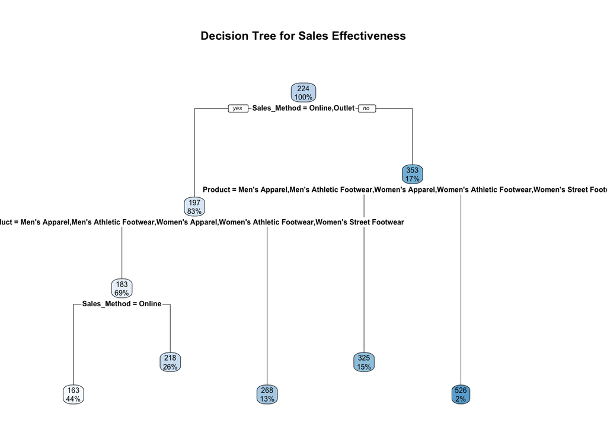

```r
rpart.plot(tree2, main = "Decision Tree for Sales Effectiveness")
```

The tree suggests that the Sales Method increases the average Units_Sold by almost 58% when selling in the stores and reduces it by almost 13% when selling in online or in an outlet. The next two splits are performed whether or not the sold product is “Men’s Street Footwear”. If it is, the average Units_Sold greatly increases. So according to this tree, the online method of sale as well as “Men’s Street Footwear” show a significant effect on the average units sold.

```r
rf2 <- ranger(Units_Sold ~ Product + Sales_Method, data = dfx, importance = "permutation")

print(rf2)
```

```
## Ranger result
##
## Call:
##  ranger(Units_Sold ~ Product + Sales_Method, data = dfx, importance = "permutation")
##
## Type:                             Regression
## Number of trees:                  500
## Sample size:                      9068
## Number of independent variables:  2
## Mtry:                             1
## Target node size:                 5
## Variable importance mode:         permutation
## Splitrule:                        variance
## OOB prediction error (MSE):       22690.79
## R squared (OOB):                  0.2010179
```

Plot the resulting permutation importance:

```r
importance <- importance(rf2)

print(importance)
```

```
##      Product Sales_Method
##     2521.733     7821.307
```

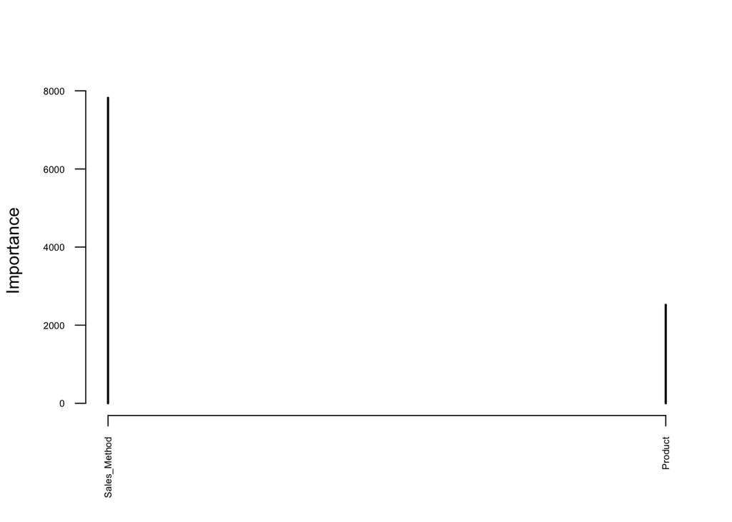

```r
importance_sorted <- sort(importance, decreasing = TRUE)
plot(as.table(importance_sorted), ylab = "Importance", las = 2, cex.axis = 0.55)
```

Once again, the variable Sales_Method is the more influential, now also on the number of Units_Sold.

Let us now focus on the third and final question we want to answer:

3. **How do different factors (product type, geographic region, price per unit)** **influence the number of units sold?**

We again look at some visualizations first:

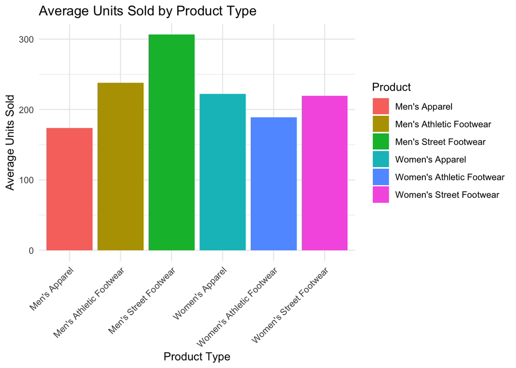

```r
# Aggregate data
agg_data_product <- dfx %>%
  group_by(Product) %>%
  summarize(Average_Units_Sold = mean(Units_Sold), .groups = 'drop')

# Plot
ggplot(agg_data_product, aes(x = Product, y = Average_Units_Sold, fill = Product)) +
  geom_bar(stat = "identity") +
  labs(title = "Average Units Sold by Product Type",
       x = "Product Type",
       y = "Average Units Sold") +
  theme_minimal() +
  theme(axis.text.x = element_text(angle = 45, hjust = 1))
```

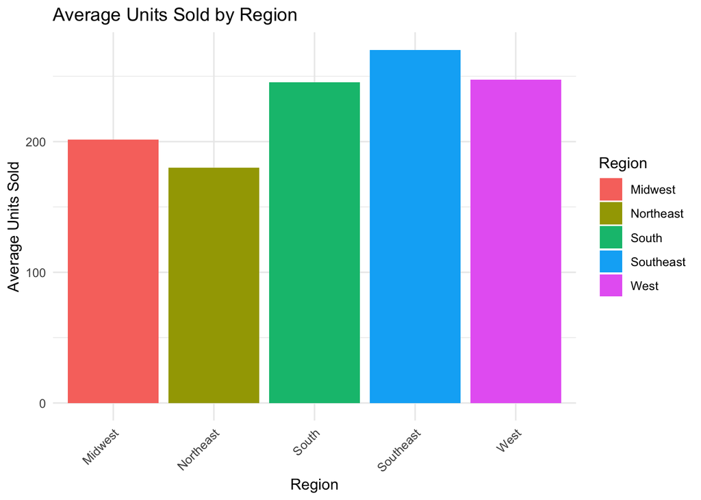

```r
# Aggregate data
agg_data_region <- dfx %>%
  group_by(Region) %>%
  summarize(Average_Units_Sold = mean(Units_Sold), .groups = 'drop')

# Plot
ggplot(agg_data_region, aes(x = Region, y = Average_Units_Sold, fill = Region)) +
  geom_bar(stat = "identity") +
  labs(title = "Average Units Sold by Region",
       x = "Region",
       y = "Average Units Sold") +
  theme_minimal() +
  theme(axis.text.x = element_text(angle = 45, hjust = 1))
```

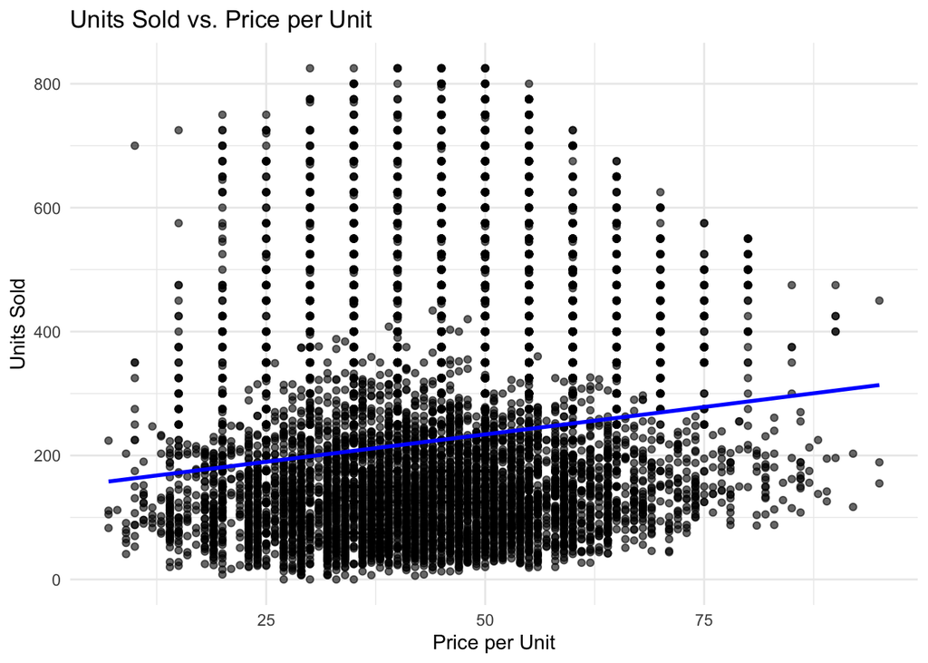

```r
ggplot(dfx, aes(x = Price_per_Unit, y = Units_Sold)) +
  geom_point(alpha = 0.6) +
  geom_smooth(method = "lm", se = FALSE, color = "blue") +
  labs(title = "Units Sold vs. Price per Unit",
       x = "Price per Unit",
       y = "Units Sold") +
  theme_minimal()
```

We can observe, that “Men’s Street Footwear” yields the most potential to have a significant impact on the average Units_Sold. Regarding the differences in regions, although Southeast shows the highest units sold, there is not a big enough difference to assume a significant impact yet. The last chart shows a slightly positive correlation between the Price per Unit and the Units sold.

We now start by fitting a multiple linear regression model on the data:

```r
reg_model <- lm(Units_Sold ~ Product + Region + Price_per_Unit, data = dfx)

summary(reg_model)
```

```
##
## Call:
## lm(formula = Units_Sold ~ Product + Region + Price_per_Unit,
##     data = dfx)
##
## Residuals:
##     Min      1Q  Median      3Q     Max
## -268.19 -110.39  -54.61   78.80  674.76
##
## Coefficients:
##                                  Estimate Std. Error t value Pr(>|t|)
## (Intercept)                       39.5553     7.9785   4.958 7.26e-07 ***
## ProductMen's Athletic Footwear    82.3358     5.7479  14.325  < 2e-16 ***
## ProductMen's Street Footwear     151.0277     5.8377  25.871  < 2e-16 ***
## ProductWomen's Apparel            49.9602     5.7397   8.704  < 2e-16 ***
## ProductWomen's Athletic Footwear  37.3381     5.7454   6.499 8.53e-11 ***
## ProductWomen's Street Footwear    71.8417     5.8240  12.335  < 2e-16 ***
## RegionNortheast                  -35.8470     4.9897  -7.184 7.29e-13 ***
## RegionSouth                       53.1590     5.3903   9.862  < 2e-16 ***
## RegionSoutheast                   50.6147     6.1108   8.283  < 2e-16 ***
## RegionWest                        25.6046     5.0506   5.070 4.07e-07 ***
## Price_per_Unit                     2.4266     0.1331  18.238  < 2e-16 ***
## ---
## Signif. codes:  0 '***' 0.001 '**' 0.01 '*' 0.05 '.' 0.1 ' ' 1
##
## Residual standard error: 157.1 on 9057 degrees of freedom
## Multiple R-squared:  0.1318, Adjusted R-squared:  0.1309
## F-statistic: 137.5 on 10 and 9057 DF,  p-value: < 2.2e-16
```

The output shows us that a simple linear regression is definately not enough to conduct an analysis, since it simply shows that all the variables and different levels are highly significant (mostly positive), combined with a very low R-squared value.

Let us once again use an interaction model:

```r
reg_interaction <- lm(Units_Sold ~ Product * Region * Price_per_Unit, data = dfx)

summary(reg_interaction)
```

```
##
## Call:
## lm(formula = Units_Sold ~ Product * Region * Price_per_Unit,
##     data = dfx)
##
## Residuals:
##     Min      1Q  Median      3Q     Max
## -265.45 -110.21  -50.08   77.80  673.37
##
## Coefficients:
##                                                                   Estimate
## (Intercept)                                                       -4.05013
## ProductMen's Athletic Footwear                                    15.93304
## ProductMen's Street Footwear                                     318.88655
## ProductWomen's Apparel                                           150.74451
## ProductWomen's Athletic Footwear                                   2.08650
## ProductWomen's Street Footwear                                    81.95425
## RegionNortheast                                                 -112.14747
## RegionSouth                                                       61.96706
## RegionSoutheast                                                  105.03011
## RegionWest                                                        61.47437
## Price_per_Unit                                                     3.16593
## ProductMen's Athletic Footwear:RegionNortheast                    -0.02984
## ProductMen's Street Footwear:RegionNortheast                     -40.74222
## ProductWomen's Apparel:RegionNortheast                             0.40603
## ProductWomen's Athletic Footwear:RegionNortheast                  61.96727
## ProductWomen's Street Footwear:RegionNortheast                    82.29951
## ProductMen's Athletic Footwear:RegionSouth                        95.03603
## ProductMen's Street Footwear:RegionSouth                         -75.44870
## ProductWomen's Apparel:RegionSouth                                -6.15631
## ProductWomen's Athletic Footwear:RegionSouth                      19.87260
## ProductWomen's Street Footwear:RegionSouth                        23.07685
## ProductMen's Athletic Footwear:RegionSoutheast                   159.26401
## ProductMen's Street Footwear:RegionSoutheast                    -153.57744
## ProductWomen's Apparel:RegionSoutheast                            15.79689
## ProductWomen's Athletic Footwear:RegionSoutheast                  63.80661
## ProductWomen's Street Footwear:RegionSoutheast                   151.92303
## ProductMen's Athletic Footwear:RegionWest                         89.10546
## ProductMen's Street Footwear:RegionWest                         -151.00402
## ProductWomen's Apparel:RegionWest                                -24.93950
```

[output cut: 205 more lines]

```
## ProductMen's Street Footwear:RegionSoutheast:Price_per_Unit     0.518144
## ProductWomen's Apparel:RegionSoutheast:Price_per_Unit           0.511137
## ProductWomen's Athletic Footwear:RegionSoutheast:Price_per_Unit 0.422214
## ProductWomen's Street Footwear:RegionSoutheast:Price_per_Unit   0.040332 *
## ProductMen's Athletic Footwear:RegionWest:Price_per_Unit        0.187046
## ProductMen's Street Footwear:RegionWest:Price_per_Unit          0.147338
## ProductWomen's Apparel:RegionWest:Price_per_Unit                0.571882
## ProductWomen's Athletic Footwear:RegionWest:Price_per_Unit      0.891380
## ProductWomen's Street Footwear:RegionWest:Price_per_Unit        0.943744
## ---
## Signif. codes:  0 '***' 0.001 '**' 0.01 '*' 0.05 '.' 0.1 ' ' 1
##
## Residual standard error: 155.8 on 9008 degrees of freedom
## Multiple R-squared:  0.1511, Adjusted R-squared:  0.1455
## F-statistic: 27.17 on 59 and 9008 DF,  p-value: < 2.2e-16
```

Interestingly, the interaction model is a lot more picky when it comes to the p-value. The most significant variables are ProductMen’s Street Footwear and Price_per_Unit, followed by ProductWomen’s Apparel. Some more interactions are significant, mainly:

ProductWomen’s Street Footwear:RegionSoutheast:Price_per_Unit ProductMen’s Athletic Footwear:RegionSoutheast:Price_per_Unit ProductMen’s Street Footwear:Price_per_Unit ProductMen’s Street Footwear:RegionWest

If we just focus on ProductWomen’s Street Footwear:RegionSoutheast:Price_per_Unit, this can be interpreted, that the effect of Price_per_Unit on Units_Sold depends on both the product category (Women’s Street Footwear) and the region (Southeast). In other words, the relationship between price and units sold for “Women’s Street Footwear” is unique in the Southeast compared to other regions or products.

..But the R-squared is still low, which can be explained by the fact that we only consider the for us relevant factors, we could include more but those variables wont help our question. Lets take a look on a regression tree…

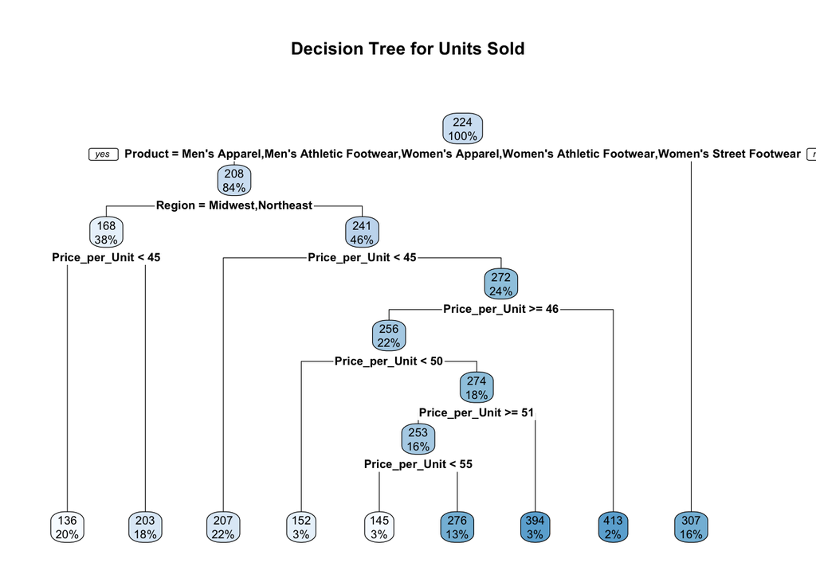

```r
tree3 <- rpart(Units_Sold ~ Product + Region + Price_per_Unit, data = dfx)

rpart.plot(tree3, main = "Decision Tree for Units Sold")
```

…and create a random forest:

```r
rf3 <- ranger(Units_Sold ~ Product + Region + Price_per_Unit, data = dfx, importance = "permutation")

print(rf3)
```

```
## Ranger result
##
## Call:
##  ranger(Units_Sold ~ Product + Region + Price_per_Unit, data = dfx,      importance = "permutation")
##
## Type:                             Regression
## Number of trees:                  500
## Sample size:                      9068
## Number of independent variables:  3
## Mtry:                             1
## Target node size:                 5
## Variable importance mode:         permutation
## Splitrule:                        variance
## OOB prediction error (MSE):       19969.37
## R squared (OOB):                  0.2968437
```

Now focus on the most important variables:

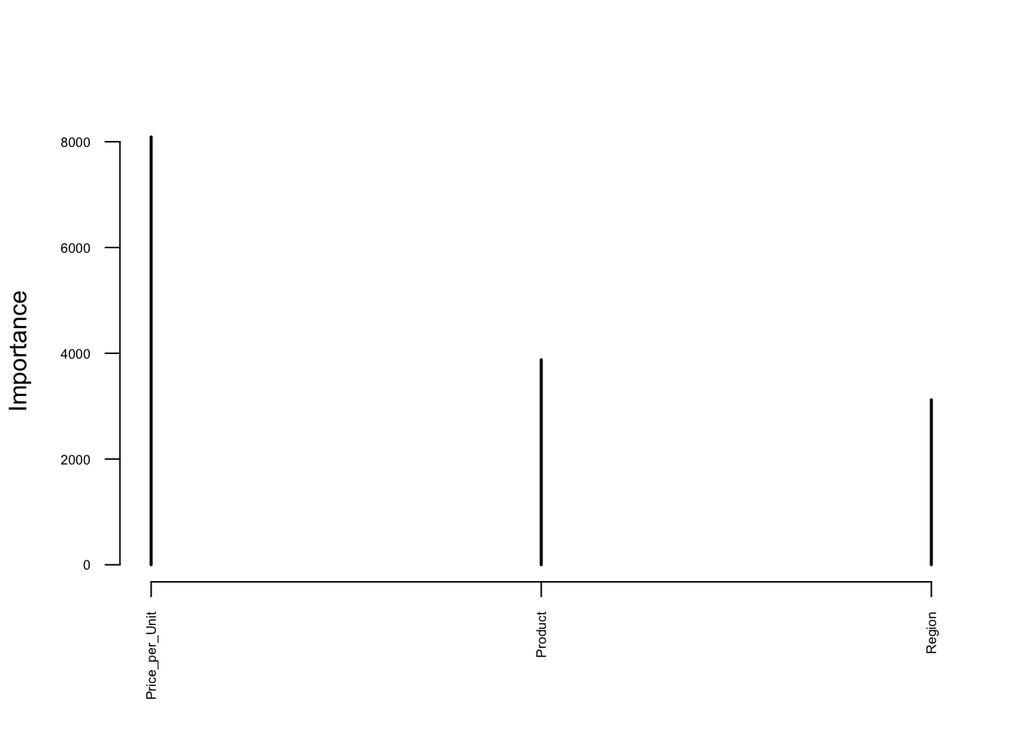

```r
importance <- importance(rf3)
importance_sorted <- sort(importance , decreasing = TRUE)
plot(as.table(importance_sorted), ylab = "Importance", las = 2, cex.axis = 0.55)
```

```r
#plot(as.table(importance(rf3)), ylab = "Importance")
```

As we can observe, the Price per Unit has the most influence towards the number of sold Units.

Now we want to perform a cross-validation and find the method, which produces the lowest MSE.

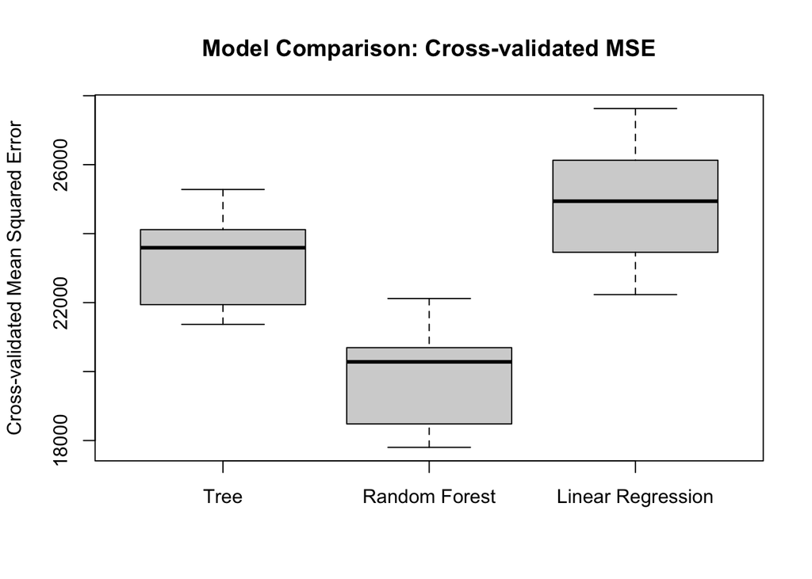

```r
n <- nrow(df1)
fold <- 10
folds <- sample(rep(1:fold, ceiling(n/fold)), n)
# head(folds, n = 10)

mse <- list(tree = numeric(fold), rf = numeric(fold), lm = numeric(fold))

for (tfold in seq_len(fold)) {
  # Split data into training and test sets
  train_idx <- which(folds != tfold)
  test_idx <- which(folds == tfold)

  # Fit models on the training set
  rf <- ranger(Units_Sold ~ Product + Region + Price_per_Unit, data = dfx[train_idx, ], importance = "permutation")
  tree <- rpart(Units_Sold ~ Product + Region + Price_per_Unit, data = dfx[train_idx, ], method = "anova")
  lm_model <- lm(Units_Sold ~ Product + Region + Price_per_Unit, data = dfx[train_idx, ])

  # Make predictions on the test set
  p_rf <- predict(rf, data = dfx[test_idx, ])$predictions
  p_tree <- predict(tree, newdata = dfx[test_idx, ])
  p_lm <- predict(lm_model, newdata = dfx[test_idx, ])

  # Calculate and store MSE
  actual <- dfx$Units_Sold[test_idx]
  mse$rf[tfold] <- mean((actual - p_rf)^2)
  mse$tree[tfold] <- mean((actual - p_tree)^2)
  mse$lm[tfold] <- mean((actual - p_lm)^2)
}

# Combine results into a data frame
mse_df <- data.frame(Tree = mse$tree, `Random Forest` = mse$rf, `Linear Regression` = mse$lm)

# Plot the cross-validated MSE
boxplot(mse_df, names = c("Tree", "Random Forest", "Linear Regression"),
        ylab = "Cross-validated Mean Squared Error",
        main = "Model Comparison: Cross-validated MSE")
```

The Random Forest outperforms the linear regression and the tree. So we come to conclusion that the Price_per_unit is the most influential factor when it comes to the number of units sold.

**Conclusion:**

Based on the findings from the first question, we recommend that retailers implement region-specific advertising and offer discounts for sales methods with lower performance. Our evaluation from the second question revealed that In-Store and Outlet Sales outperform Online Sales, suggesting that enhanced online marketing efforts and strategic discounting could positively impact sales performance. For the third question, we presented a geographical distribution plot, which can help refine advertising and discount strategies. Additionally, the decision tree analysis offers valuable insights into customer price sensitivity, aiding in more targeted decision-making. Combining all these findings: Adidas should focus on region-specific advertising and optimize underperforming sales channels, particularly by enhancing online marketing efforts and offering targeted discounts to boost e-commerce performance. Additionally, leveraging geographical distribution insights and understanding customer price sensitivity can help refine marketing strategies and maximize overall sales potential.